# Aleutian Scorpionfish

*Adelosebastes latens*

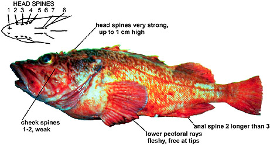

**Body color:** Bright crimson red; dusky mottling on back forming 3 faint saddles; ventral pectoral rays pink; dusky area on dorsal-most pectoral rays.

**Peritoneum color:** gray w/ black spots **Shape between eyes:** concave

**Counts:** D:XII,12-13, Ar:5, P1:18-22, GR:24-25, LLp:28-29, LLs:74-100, V:26

**Occurence:** Aleutian Islands

**Depth:** 1200 meters **Size:** 41 cm **Species code:** 30035

Back to Group

**Corrections:** If you see mistakes or want to suggest changes, please create an [issue](https://github.com/zoyafuso-NOAA/RACE_Survey_App/issues) on the source repository or

*reach out to Liz Dawson (Liz.Dawson AT noaa.gov).*